# trajeto

### Eficiência na Rota de Entregas - Otimização de Operações Logísticas com Machine Learning

Notebook criado para o Desafio Técnico.

Das variáveis entregues no problema, decidi usar apenas as descritas abaixo. Pois são as relevantes para o a estimativa - Tempo Estimado de Viagem - foco do Modelo de Machine Learning - prever qual o tempo necessário para levar o item do ponto de partida ao destino de entrega, com as dependências do ambiente.

#### Workflow:

1. Codificar os valores possíveis para 'Local de Partida', 'Destino da Entrega' e 'Condições de Tráfego';
2. Configurar para 'target' de predicção do modelo - 'Tempo Estimado de Viagem'
3. Configurar o Modelo - Random Forest Regressor - e analisar precisão

```python
import pandas as pd
import numpy as np

# Dados recebidos para simulação

np.random.seed(2)

entregas_data = pd.DataFrame({
    'ID da Entrega': range(1, 101),
    'ID do Veículo': np.random.choice(['V1', 'V2', 'V3', 'V4'], 100),
    'Local de Partida': np.random.choice(['CD1', 'CD2', 'CD3'], 100),
    'Destino da Entrega': np.random.choice(['Local A', 'Local B', 'Local C', 'Local D', 'Local E'], 100),
    'Distância': np.random.uniform(10, 300, 100),  # Distância em km
    'Tempo Estimado de Viagem': np.random.uniform(30, 240, 100),  # Tempo em minutos
    'Condições de Tráfego': np.random.choice(['Baixo', 'Médio', 'Alto'], 100)
})

entregas_data.head()
```

|  | ID da Entrega | ID do Veículo | Local de Partida | Destino da Entrega | Distância | Tempo Estimado de Viagem | Condições de Tráfego |
| --- | --- | --- | --- | --- | --- | --- | --- |
| 0 | 1 | V1 | CD3 | Local E | 236.287542 | 129.517510 | Alto |
| 1 | 2 | V4 | CD1 | Local C | 133.532678 | 150.633732 | Médio |
| 2 | 3 | V2 | CD3 | Local A | 110.368464 | 117.425770 | Médio |
| 3 | 4 | V1 | CD2 | Local D | 166.362959 | 57.964237 | Baixo |
| 4 | 5 | V3 | CD1 | Local D | 135.052033 | 99.437949 | Alto |

**Escolha do Modelo**

Por haver algumas features com informações não-lineares, decidi utilizar o **Random Forest Regressor**, que utiliza árvore de decisão, sem envolver algoritmos lineares.

**Início do Preparo do Modelo:**

Usando Label Encoder e StandardScaler para separar cada categoria em códigos numéricos e escalar os valores, respectivamente. Escalar valores aqui é importante, pois as features são muito distintas entre si (Destino de Entrega e Distância, por exemplo).

```python
from sklearn.preprocessing import LabelEncoder, StandardScaler
from sklearn.model_selection import train_test_split
from sklearn.ensemble import RandomForestRegressor
from sklearn.metrics import mean_squared_error

# Codificar variáveis categóricas
label_encoders = {}
for column in ['Local de Partida', 'Destino da Entrega', 'Condições de Tráfego']:
    le = LabelEncoder()
    entregas_data[column] = le.fit_transform(entregas_data[column])
    label_encoders[column] = le

# Normalizar Distância
scaler = StandardScaler()
entregas_data[['Distância']] = scaler.fit_transform(entregas_data[['Distância']])

# Definir o que é feature e o que é target
X = entregas_data[['Local de Partida', 'Destino da Entrega', 'Distância', 'Condições de Tráfego']]
y = entregas_data['Tempo Estimado de Viagem']

# Dividir os dados em conjuntos de treino e teste
X_train, X_test, y_train, y_test = train_test_split(X, y, test_size=0.3, random_state=2)

# Treinar o modelo
model = RandomForestRegressor(n_estimators=100, random_state=2)
_ = model.fit(X_train, y_train)

# Avaliação do Modelo
y_pred = model.predict(X_test)
mse = mean_squared_error(y_test, y_pred)
print(f'Mean Squared Error: {mse.round(2)}')
```

```
Mean Squared Error: 5543.8
```

**Análises do Modelo** Avaliar erro e precisão é tarefa importante, como visto acima (Mean Squared Error). Entretanto, por se tratar de valores grandes de tempo, o ideal é fornecer um gráfico para acompanhar a análise. Comparar os valores reais dos previstos, também com a estimativa

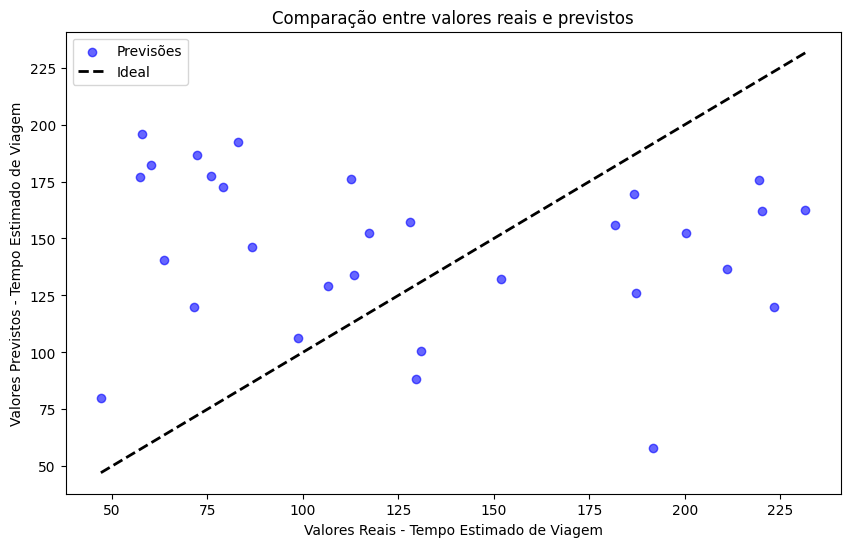

```python
import matplotlib.pyplot as plt
# Plotar gráfico de comparação entre valores reais e previstos
plt.figure(figsize=(10, 6))
plt.scatter(y_test, y_pred, color='blue', label='Previsões', alpha=0.6)
plt.plot([y_test.min(), y_test.max()], [y_test.min(), y_test.max()], 'k--', lw=2, label='Ideal')
plt.xlabel('Valores Reais - Tempo Estimado de Viagem')
plt.ylabel('Valores Previstos - Tempo Estimado de Viagem')
plt.title('Comparação entre valores reais e previstos')
plt.legend()
```